# Credit Card Fraud Detection

### **Conclusion:**

#### **Proceed with the model which shows the best result**

- Apply the best hyperparameter on the model
- Predict on the test dataset

```python
# Logistic Regression
from sklearn import linear_model #import the package
from sklearn.model_selection import KFold

num_C = list(np.power(10.0, np.arange(-10, 10)))
cv_num = KFold(n_splits=10, shuffle=True, random_state=42)

clf = linear_model.LogisticRegressionCV(
          Cs= num_C
          ,penalty='l2'
          ,scoring='roc_auc'
          ,cv=cv_num
          ,random_state=42
          ,max_iter=10000
          ,fit_intercept=True
          ,solver='newton-cg'
          ,tol=10
      )

clf.fit(X_train_SKF_cv, y_train_SKF_cv)
print ('Max auc_roc for l2:', clf.scores_[1].mean(axis=0).max())


print("Parameters for l2 regularisations")
print(clf.coef_)
print(clf.intercept_)
print(clf.scores_)


#find predicted vallues
y_pred_l2 = clf.predict(X_test)


#Find predicted probabilities
y_pred_probs_l2 = clf.predict_proba(X_test)[:,1]


# Accuaracy of L2/L1 models
Accuracy_l2 = metrics.accuracy_score(y_pred=y_pred_l2, y_true=y_test)


print("Accuarcy of Logistic model with l2 regularisation : {0}".format(Accuracy_l2))


from sklearn.metrics import roc_auc_score
l2_roc_value = roc_auc_score(y_test, y_pred_probs_l2)
print("l2 roc_value: {0}" .format(l2_roc_value))
fpr, tpr, thresholds = metrics.roc_curve(y_test, y_pred_probs_l2)
threshold = thresholds[np.argmax(tpr-fpr)]
print("l2 threshold: {0}".format(threshold))
```

```
Max auc_roc for l2: 0.9567308642474954
Parameters for l2 regularisations
[[-1.31491217e-02  3.07463695e-02 -1.23758286e-01  2.90976907e-01
   1.00763702e-01 -5.25175254e-02  4.50978185e-02 -1.31263201e-01
  -1.08854534e-01 -1.56738327e-01  1.83509896e-01 -2.25403516e-01
  -5.45158708e-02 -4.16368675e-01 -5.45595030e-02 -7.19437239e-02
  -1.10316217e-01 -2.06331993e-02  2.04222421e-02 -2.72144122e-02
   4.33597690e-02  6.29205995e-02  3.69527095e-02 -1.48824898e-02
  -1.39901365e-02  2.51950981e-03 -4.00624298e-03 -7.95897195e-02
   3.42612078e-04  1.20704152e-02]]
[-7.64242687]
{1: array([[0.65944862, 0.65944862, 0.66107769, 0.67919799, 0.77882206,
        0.84032581, 0.88531328, 0.92263158, 0.9356391 , 0.93924812,
        0.93924812, 0.93924812, 0.93924812, 0.93924812, 0.93924812,
        0.93924812, 0.93924812, 0.93924812, 0.93924812, 0.93924812],
       [0.55307962, 0.55307962, 0.55474879, 0.58771491, 0.73147221,
        0.84848105, 0.87819229, 0.90110165, 0.91103322, 0.89542647,
        0.89542647, 0.89542647, 0.89542647, 0.89542647, 0.89542647,
        0.89542647, 0.89542647, 0.89542647, 0.89542647, 0.89542647],
       [0.49772817, 0.49772817, 0.49898036, 0.52584881, 0.67553934,
        0.87138206, 0.94204143, 0.97273801, 0.98007227, 0.98443705,
        0.98443705, 0.98443705, 0.98443705, 0.98443705, 0.98443705,
        0.98443705, 0.98443705, 0.98443705, 0.98443705, 0.98443705],
       [0.58863726, 0.58860148, 0.59024722, 0.61833208, 0.79202891,
        0.9631498 , 0.9797145 , 0.92626382, 0.90862581, 0.91062932,
        0.91062932, 0.91062932, 0.91062932, 0.91062932, 0.91062932,
        0.91062932, 0.91062932, 0.91062932, 0.91062932, 0.91062932],
       [0.89706987, 0.89692676, 0.89774963, 0.90143465, 0.92533362,
        0.9622196 , 0.93864262, 0.95302494, 0.98339952, 0.98164645,
        0.98164645, 0.98164645, 0.98164645, 0.98164645, 0.98164645,
        0.98164645, 0.98164645, 0.98164645, 0.98164645, 0.98164645],
       [0.50973823, 0.50973823, 0.51111598, 0.53710546, 0.66846192,
        0.79950526, 0.90812876, 0.97263277, 0.96940757, 0.96157941,
        0.9332728 , 0.9332728 , 0.9332728 , 0.9332728 , 0.9332728 ,
        0.9332728 , 0.9332728 , 0.9332728 , 0.9332728 , 0.9332728 ],
       [0.51582833, 0.51582833, 0.51607858, 0.52152152, 0.57645145,
        0.76295045, 0.90546797, 0.90934685, 0.9288038 , 0.87825325,
        0.87825325, 0.87825325, 0.87825325, 0.87825325, 0.87825325,
        0.87825325, 0.87825325, 0.87825325, 0.87825325, 0.87825325],
       [0.41166166, 0.41166166, 0.41278779, 0.44575826, 0.6265015 ,
        0.80974725, 0.9004004 , 0.94513263, 0.95952202, 0.95658158,
        0.95658158, 0.94331832, 0.94331832, 0.94331832, 0.94331832,
        0.94331832, 0.94331832, 0.94331832, 0.94331832, 0.94331832],
       [0.554041  , 0.554041  , 0.55550785, 0.57096347, 0.69085185,
        0.88064828, 0.9584988 , 0.98533147, 0.99080534, 0.98966048,
        0.98966048, 0.98966048, 0.98966048, 0.98966048, 0.98966048,
        0.98966048, 0.98966048, 0.98966048, 0.98966048, 0.98966048],
       [0.33032807, 0.33022074, 0.33458552, 0.38728489, 0.68140675,
        0.94451004, 0.99745984, 0.99992845, 1.        , 1.        ,
        1.        , 1.        , 1.        , 1.        , 1.        ,
        1.        , 1.        , 1.        , 1.        , 1.        ]])}
Accuarcy of Logistic model with l2 regularisation : 0.9995
l2 roc_value: 0.9785411450509097
l2 threshold: 0.008174170065796222
```

```python
# Checking for the coefficient values
clf.coef_
```

```
array([[-1.31491217e-02,  3.07463695e-02, -1.23758286e-01,
         2.90976907e-01,  1.00763702e-01, -5.25175254e-02,
         4.50978185e-02, -1.31263201e-01, -1.08854534e-01,
        -1.56738327e-01,  1.83509896e-01, -2.25403516e-01,
        -5.45158708e-02, -4.16368675e-01, -5.45595030e-02,
        -7.19437239e-02, -1.10316217e-01, -2.06331993e-02,
         2.04222421e-02, -2.72144122e-02,  4.33597690e-02,
         6.29205995e-02,  3.69527095e-02, -1.48824898e-02,
        -1.39901365e-02,  2.51950981e-03, -4.00624298e-03,
        -7.95897195e-02,  3.42612078e-04,  1.20704152e-02]])
```

```python
# Creating a dataframe with the coefficient values
coefficients = pd.concat([pd.DataFrame(X.columns),pd.DataFrame(np.transpose(clf.coef_))], axis = 1)
coefficients.columns = ['Feature','Importance Coefficient']
```

```python
coefficients
```

|  | Feature | Importance Coefficient |
| --- | --- | --- |
| 0 | V1 | -0.013149 |
| 1 | V2 | 0.030746 |
| 2 | V3 | -0.123758 |
| 3 | V4 | 0.290977 |
| 4 | V5 | 0.100764 |
| 5 | V6 | -0.052518 |
| 6 | V7 | 0.045098 |
| 7 | V8 | -0.131263 |
| 8 | V9 | -0.108855 |
| 9 | V10 | -0.156738 |
| 10 | V11 | 0.183510 |
| 11 | V12 | -0.225404 |
| 12 | V13 | -0.054516 |
| 13 | V14 | -0.416369 |
| 14 | V15 | -0.054560 |
| 15 | V16 | -0.071944 |
| 16 | V17 | -0.110316 |
| 17 | V18 | -0.020633 |
| 18 | V19 | 0.020422 |
| 19 | V20 | -0.027214 |
| 20 | V21 | 0.043360 |
| 21 | V22 | 0.062921 |
| 22 | V23 | 0.036953 |
| 23 | V24 | -0.014882 |
| 24 | V25 | -0.013990 |
| 25 | V26 | 0.002520 |
| 26 | V27 | -0.004006 |
| 27 | V28 | -0.079590 |
| 28 | Amount | 0.000343 |
| 29 | Time_Hour | 0.012070 |

### **Print the important features of the best model to understand the dataset**

- This will not give much explanation on the already transformed dataset
- But it will help us in understanding if the dataset is not PCA transformed

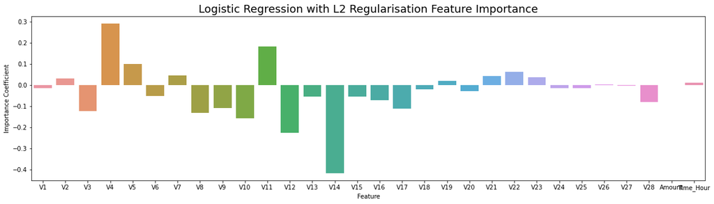

```python
# Plotting the coefficient values
plt.figure(figsize=(20,5))
sns.barplot(x='Feature', y='Importance Coefficient', data=coefficients)
plt.title("Logistic Regression with L2 Regularisation Feature Importance", fontsize=18)

plt.show()
```

- Hence it implies that V4, v5,V11 has + ve importance whereas V10, V12, V14 seems to have -ve impact on the predictaions

## **Model building with balancing Classes**

### **Perform class balancing with:**

- Random Oversampling
- SMOTE
- ADASYN

## Oversampling with RandomOverSampler with StratifiedKFold Cross Validation

- **Random Oversampling:**
  - Random Oversampling is a technique for handling imbalanced datasets by duplicating instances from the minority class to balance the class distribution.
  - This method increases the number of samples in the minority class to compensate for the class imbalance, but it can also lead to overfitting, as it increases the likelihood of duplicating instances in the training set.

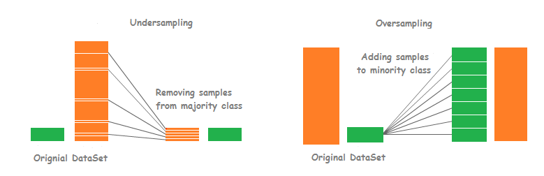

```python
# Creating the dataset with RandomOverSampler and StratifiedKFold
from sklearn.model_selection import StratifiedKFold
from imblearn.over_sampling import RandomOverSampler

skf = StratifiedKFold(n_splits=5, random_state=None)

for fold, (train_index, test_index) in enumerate(skf.split(X,y), 1):
    # print(fold,train_index, test_index)
    X_train = X.iloc[train_index]
    y_train = y.iloc[train_index]
    X_test = X.iloc[test_index]
    y_test = y.iloc[test_index]
    ROS = RandomOverSampler(sampling_strategy=0.5)
    X_over, y_over= ROS.fit_resample(X_train, y_train)

X_over = pd.DataFrame(data=X_over, columns=cols)
```

```
Logistic Regression with L1 And L2 Regularisation
Max auc_roc for l1: 0.5
Max auc_roc for l2: 0.9902811135417251
Parameters for l1 regularisations
[[0. 0. 0. 0. 0. 0. 0. 0. 0. 0. 0. 0. 0. 0. 0. 0. 0. 0. 0. 0. 0. 0. 0. 0.
  0. 0. 0. 0. 0. 0.]]
[0.]
{1: array([[0.5, 0.5, 0.5, 0.5, 0.5, 0.5, 0.5, 0.5, 0.5, 0.5, 0.5, 0.5, 0.5,
        0.5, 0.5, 0.5, 0.5, 0.5, 0.5, 0.5],
       [0.5, 0.5, 0.5, 0.5, 0.5, 0.5, 0.5, 0.5, 0.5, 0.5, 0.5, 0.5, 0.5,
        0.5, 0.5, 0.5, 0.5, 0.5, 0.5, 0.5],
       [0.5, 0.5, 0.5, 0.5, 0.5, 0.5, 0.5, 0.5, 0.5, 0.5, 0.5, 0.5, 0.5,
        0.5, 0.5, 0.5, 0.5, 0.5, 0.5, 0.5],
       [0.5, 0.5, 0.5, 0.5, 0.5, 0.5, 0.5, 0.5, 0.5, 0.5, 0.5, 0.5, 0.5,
        0.5, 0.5, 0.5, 0.5, 0.5, 0.5, 0.5],
       [0.5, 0.5, 0.5, 0.5, 0.5, 0.5, 0.5, 0.5, 0.5, 0.5, 0.5, 0.5, 0.5,
        0.5, 0.5, 0.5, 0.5, 0.5, 0.5, 0.5],
       [0.5, 0.5, 0.5, 0.5, 0.5, 0.5, 0.5, 0.5, 0.5, 0.5, 0.5, 0.5, 0.5,
        0.5, 0.5, 0.5, 0.5, 0.5, 0.5, 0.5],
       [0.5, 0.5, 0.5, 0.5, 0.5, 0.5, 0.5, 0.5, 0.5, 0.5, 0.5, 0.5, 0.5,
        0.5, 0.5, 0.5, 0.5, 0.5, 0.5, 0.5],
       [0.5, 0.5, 0.5, 0.5, 0.5, 0.5, 0.5, 0.5, 0.5, 0.5, 0.5, 0.5, 0.5,
        0.5, 0.5, 0.5, 0.5, 0.5, 0.5, 0.5],
       [0.5, 0.5, 0.5, 0.5, 0.5, 0.5, 0.5, 0.5, 0.5, 0.5, 0.5, 0.5, 0.5,
        0.5, 0.5, 0.5, 0.5, 0.5, 0.5, 0.5],
       [0.5, 0.5, 0.5, 0.5, 0.5, 0.5, 0.5, 0.5, 0.5, 0.5, 0.5, 0.5, 0.5,
        0.5, 0.5, 0.5, 0.5, 0.5, 0.5, 0.5]])}
Parameters for l2 regularisations
[[ 1.00287017  1.75499432  0.65939176  0.96551128  1.33001016 -0.68910098
  -0.41794128  0.10929295  0.32371588 -1.23855061  1.0777743  -0.84159353
  -0.27422317 -1.78960219  0.09829525  0.81281043 -1.39714535 -1.7745295
   1.70662517 -1.0846819  -1.21053154  1.11054779  1.62081414 -0.01230903
   1.13104885 -1.04185668  1.09879398  1.8527709   0.01426082  0.04171269]]
[-6.89355115]
{1: array([[0.56755895, 0.59439814, 0.70231474, 0.85220335, 0.93222631,
        0.9652848 , 0.9768219 , 0.98400971, 0.98808398, 0.98903956,
        0.98921246, 0.98921246, 0.98921246, 0.98921246, 0.98921246,
        0.98921246, 0.98921246, 0.98921246, 0.98921246, 0.98921246],
       [0.58162639, 0.60675551, 0.71086415, 0.85593627, 0.93524667,
        0.96812634, 0.97844339, 0.98484704, 0.98810019, 0.9892657 ,
```

[output cut: 21 more lines]

```
        0.99100381, 0.99100381, 0.99100381, 0.99100381, 0.99100381],
       [0.56412245, 0.59072964, 0.70228613, 0.85572542, 0.93379845,
        0.96823649, 0.97935214, 0.98627608, 0.98955185, 0.99062136,
        0.99091057, 0.99091057, 0.99091057, 0.99091057, 0.99091057,
        0.99091057, 0.99091057, 0.99091057, 0.99091057, 0.99091057],
       [0.55289919, 0.58075621, 0.69678641, 0.85645818, 0.93641018,
        0.96878613, 0.97901316, 0.98563259, 0.98928921, 0.99040971,
        0.9906853 , 0.9906853 , 0.9906853 , 0.9906853 , 0.9906853 ,
        0.9906853 , 0.9906853 , 0.9906853 , 0.9906853 , 0.9906853 ],
       [0.56355412, 0.59193147, 0.70231962, 0.85884523, 0.93792208,
        0.97001416, 0.97828892, 0.98478536, 0.98906349, 0.99048169,
        0.99078304, 0.99078304, 0.99078304, 0.99078304, 0.99078304,
        0.99078304, 0.99078304, 0.99078304, 0.99078304, 0.99078304]])}
Accuarcy of Logistic model with l2 regularisation : 0.9808
Confusion Matrix
```

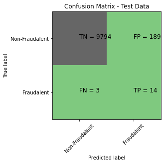

```
classification Report
              precision    recall  f1-score   support

           0       1.00      0.98      0.99      9983
           1       0.07      0.82      0.13        17

    accuracy                           0.98     10000
   macro avg       0.53      0.90      0.56     10000
weighted avg       1.00      0.98      0.99     10000

Accuarcy of Logistic model with l1 regularisation : 0.9983
Confusion Matrix
```

```
classification Report
              precision    recall  f1-score   support

           0       1.00      1.00      1.00      9983
           1       0.00      0.00      0.00        17

    accuracy                           1.00     10000
   macro avg       0.50      0.50      0.50     10000
weighted avg       1.00      1.00      1.00     10000

l2 roc_value: 0.9630784097671925
l2 threshold: 0.3837371155321852
ROC for the test dataset 96.3%
```

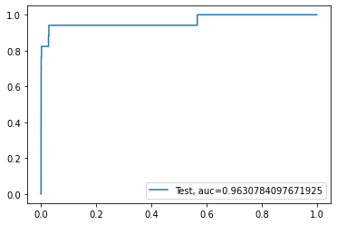

```
l1 roc_value: 0.5
l1 threshold: 1.5
ROC for the test dataset 50.0%
```

```
Time Taken by Model: --- 99.70262217521667 seconds ---
------------------------------------------------------------
KNN Model
model score
0.9986
Confusion Matrix
```

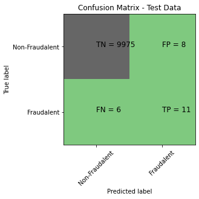

```
classification Report
              precision    recall  f1-score   support

           0       1.00      1.00      1.00      9983
           1       0.58      0.65      0.61        17

    accuracy                           1.00     10000
   macro avg       0.79      0.82      0.81     10000
weighted avg       1.00      1.00      1.00     10000

KNN roc_value: 0.823164084826558
KNN threshold: 0.6
ROC for the test dataset 82.3%
```

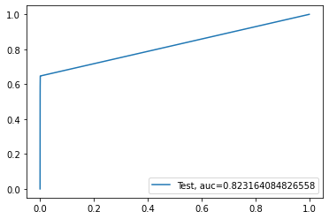

```
Time Taken by Model: --- 76.98786473274231 seconds ---
------------------------------------------------------------
Decision Tree Models with  'gini' & 'entropy' criteria
gini score: 0.9987
Confusion Matrix
```

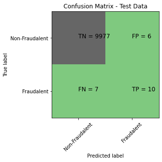

```
classification Report
              precision    recall  f1-score   support

           0       1.00      1.00      1.00      9983
           1       0.62      0.59      0.61        17

    accuracy                           1.00     10000
   macro avg       0.81      0.79      0.80     10000
weighted avg       1.00      1.00      1.00     10000

gini tree_roc_value: 0.7938171361903471
Tree threshold: 1.0
ROC for the test dataset 79.4%
```

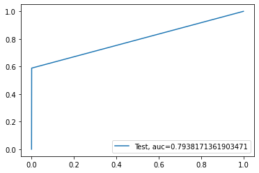

```
entropy score: 0.9991
Confusion Matrix
```

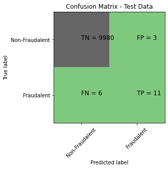

```
classification Report
              precision    recall  f1-score   support

           0       1.00      1.00      1.00      9983
           1       0.79      0.65      0.71        17

    accuracy                           1.00     10000
   macro avg       0.89      0.82      0.85     10000
weighted avg       1.00      1.00      1.00     10000

entropy tree_roc_value: 0.8233791563304677
Tree threshold: 1.0
ROC for the test dataset 82.3%
```

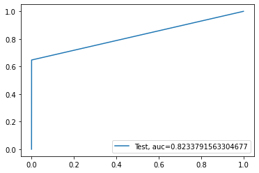

```
Time Taken by Model: --- 2.96124267578125 seconds ---
------------------------------------------------------------
Random Forest Model
Model Accuracy: 0.9994
Confusion Matrix
```

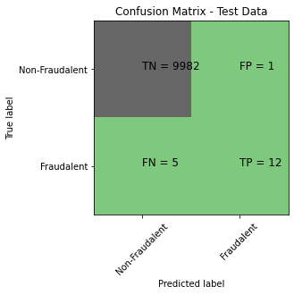

```
classification Report
              precision    recall  f1-score   support

           0       1.00      1.00      1.00      9983
           1       0.92      0.71      0.80        17

    accuracy                           1.00     10000
   macro avg       0.96      0.85      0.90     10000
weighted avg       1.00      1.00      1.00     10000

Random Forest roc_value: 0.9378914743298901
Random Forest threshold: 0.02
ROC for the test dataset 93.8%
```

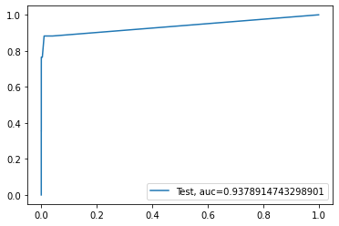

```
Time Taken by Model: --- 17.280887126922607 seconds ---
------------------------------------------------------------
XGBoost Model
Model Accuracy: 0.9992
Confusion Matrix
```

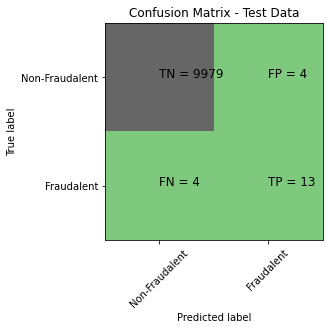

```
classification Report
              precision    recall  f1-score   support

           0       1.00      1.00      1.00      9983
           1       0.76      0.76      0.76        17

    accuracy                           1.00     10000
   macro avg       0.88      0.88      0.88     10000
weighted avg       1.00      1.00      1.00     10000

XGboost roc_value: 0.9714750369746215
XGBoost threshold: 0.13544505834579468
ROC for the test dataset 97.1%
```

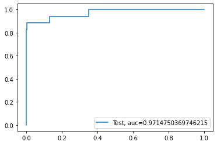

```
Time Taken by Model: --- 11.824404954910278 seconds ---
------------------------------------------------------------
ANN Model
accuracy_score : 0.9991
Confusion Matrix
```

[2 more figures not shown]

```
Time Taken by Model: --- 38.464799880981445 seconds ---
--------------------------------------------------------------------------------
```

```python
Data_Imbalance_Handiling	 = "Random Oversampling with StratifiedKFold CV "
#Run Logistic Regression with L1 And L2 Regularisation
print("Logistic Regression with L1 And L2 Regularisation")
start_time = time.time()
df_Results = buildAndRunLogisticModels(df_Results , Data_Imbalance_Handiling , X_over, y_over, X_test, y_test)
print("Time Taken by Model: --- %s seconds ---" % (time.time() - start_time))
print('-'*60 )

#Run KNN Model
print("KNN Model")
start_time = time.time()
df_Results = buildAndRunKNNModels(df_Results , Data_Imbalance_Handiling,X_over, y_over, X_test, y_test)
print("Time Taken by Model: --- %s seconds ---" % (time.time() - start_time))
print('-'*60 )

#Run Decision Tree Models with  'gini' & 'entropy' criteria
print("Decision Tree Models with  'gini' & 'entropy' criteria")
start_time = time.time()
df_Results = buildAndRunTreeModels(df_Results , Data_Imbalance_Handiling,X_over, y_over, X_test, y_test)
print("Time Taken by Model: --- %s seconds ---" % (time.time() - start_time))
print('-'*60 )

#Run Random Forest Model
print("Random Forest Model")
start_time = time.time()
df_Results = buildAndRunRandomForestModels(df_Results , Data_Imbalance_Handiling,X_over, y_over, X_test, y_test)
print("Time Taken by Model: --- %s seconds ---" % (time.time() - start_time))
print('-'*60 )

#Run XGBoost Model
print("XGBoost Model")
start_time = time.time()
df_Results = buildAndRunXGBoostModels(df_Results , Data_Imbalance_Handiling,X_over, y_over, X_test, y_test)
print("Time Taken by Model: --- %s seconds ---" % (time.time() - start_time))
print('-'*60 )

#Run ANN Model
print("ANN Model")
start_time = time.time()
df_Results = buildAndgetmetricsANN(df_Results, Data_Imbalance_Handiling, X_train_Smote, y_train_Smote , X_test, y_test)
print("Time Taken by Model: --- %s seconds ---" % (time.time() - start_time))
print('-'*80 )
```

```python
# Checking the df_result dataframe which contains consolidated results of all the runs
df_Results
```

|  | Methodology | Model | Accuracy | roc_value | threshold |
| --- | --- | --- | --- | --- | --- |
| 0 | RepeatedKFold Cross Validation | Logistic Regression with L2 Regularisation | 0.9990 | 0.950886 | 0.030690 |
| 1 | RepeatedKFold Cross Validation | Logistic Regression with L1 Regularisation | 0.9991 | 0.933580 | 0.057833 |
| 2 | RepeatedKFold Cross Validation | KNN | 0.9990 | 0.866296 | 0.200000 |
| 3 | RepeatedKFold Cross Validation | Tree Model with gini criteria | 0.9989 | 0.833033 | 1.000000 |
| 4 | RepeatedKFold Cross Validation | Tree Model with entropy criteria | 0.9992 | 0.899750 | 1.000000 |
| 5 | RepeatedKFold Cross Validation | Random Forest | 0.9997 | 0.965381 | 0.300000 |
| 6 | RepeatedKFold Cross Validation | XGBoost | 0.9996 | 0.936365 | 0.283122 |
| 7 | RepeatedKFold Cross Validation | SVM | 0.9981 | 0.724487 | 0.003482 |
| 8 | RepeatedKFold Cross Validation | ANN | 0.9984 | 0.927278 | 0.000521 |
| 9 | StratifiedKFold Cross Validation | Logistic Regression with L2 Regularisation | 0.9992 | 0.956638 | 0.002113 |
| 10 | StratifiedKFold Cross Validation | Logistic Regression with L1 Regularisation | 0.9991 | 0.892559 | 0.301463 |
| 11 | StratifiedKFold Cross Validation | KNN | 0.9990 | 0.823250 | 0.200000 |
| 12 | StratifiedKFold Cross Validation | Tree Model with gini criteria | 0.9985 | 0.823079 | 1.000000 |
| 13 | StratifiedKFold Cross Validation | Tree Model with entropy criteria | 0.9990 | 0.823329 | 1.000000 |
| 14 | StratifiedKFold Cross Validation | Random Forest | 0.9995 | 0.937102 | 0.010000 |
| 15 | StratifiedKFold Cross Validation | XGBoost | 0.9993 | 0.971463 | 0.001395 |
| 16 | StratifiedKFold Cross Validation | SVM | 0.9975 | 0.634779 | 0.003424 |
| 17 | StratifiedKFold Cross Validation | ANN | 0.9985 | 0.925528 | 0.000077 |
| 18 | Random Oversampling with StratifiedKFold CV | Logistic Regression with L2 Regularisation | 0.9808 | 0.963078 | 0.383737 |
| 19 | Random Oversampling with StratifiedKFold CV | Logistic Regression with L1 Regularisation | 0.9983 | 0.500000 | 1.500000 |
| 20 | Random Oversampling with StratifiedKFold CV | KNN | 0.9986 | 0.823164 | 0.600000 |
| 21 | Random Oversampling with StratifiedKFold CV | Tree Model with gini criteria | 0.9987 | 0.793817 | 1.000000 |
| 22 | Random Oversampling with StratifiedKFold CV | Tree Model with entropy criteria | 0.9991 | 0.823379 | 1.000000 |
| 23 | Random Oversampling with StratifiedKFold CV | Random Forest | 0.9994 | 0.937891 | 0.020000 |
| 24 | Random Oversampling with StratifiedKFold CV | XGBoost | 0.9992 | 0.971475 | 0.135445 |
| 25 | Random Oversampling with StratifiedKFold CV | ANN | 0.9991 | 0.946933 | 0.000007 |

### **Results for Random Oversampling with StratifiedKFold technique:**

- Looking at the Accuracy and ROC value we have XGBoost which has provided best results for Random Oversampling and StratifiedKFold technique

## Oversampling with SMOTE Oversampling

**SMOTE (Synthetic Minority Over-sampling Technique):**

- SMOTE (Synthetic Minority Over-sampling Technique) is a data augmentation technique for handling imbalanced datasets by creating synthetic samples for the minority class.
- SMOTE generates new instances for the minority class by interpolating between existing instances and their nearest neighbors, creating a more diverse representation of the minority class. This can help balance the class distribution and prevent overfitting due to random oversampling.

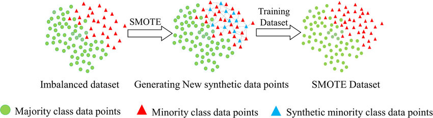

```python
# Creating dataframe with Smote and StratifiedKFold
from sklearn.model_selection import StratifiedKFold
from imblearn import over_sampling

skf = StratifiedKFold(n_splits=5, random_state=None)

for fold, (train_index, test_index) in enumerate(skf.split(X,y), 1):
    X_train = X.iloc[train_index]
    y_train = y.iloc[train_index]
    X_test = X.iloc[test_index]
    y_test = y.iloc[test_index]
    SMOTE = over_sampling.SMOTE(random_state=0)
    X_train_Smote, y_train_Smote= SMOTE.fit_resample(X_train, y_train)

X_train_Smote = pd.DataFrame(data=X_train_Smote,   columns=cols)
```

```
Logistic Regression with L1 And L2 Regularisation
Max auc_roc for l1: 0.5
Max auc_roc for l2: 0.9937543557426121
Parameters for l1 regularisations
[[0. 0. 0. 0. 0. 0. 0. 0. 0. 0. 0. 0. 0. 0. 0. 0. 0. 0. 0. 0. 0. 0. 0. 0.
  0. 0. 0. 0. 0. 0.]]
[0.]
{1: array([[0.5, 0.5, 0.5, 0.5, 0.5, 0.5, 0.5, 0.5, 0.5, 0.5, 0.5, 0.5, 0.5,
        0.5, 0.5, 0.5, 0.5, 0.5, 0.5, 0.5],
       [0.5, 0.5, 0.5, 0.5, 0.5, 0.5, 0.5, 0.5, 0.5, 0.5, 0.5, 0.5, 0.5,
        0.5, 0.5, 0.5, 0.5, 0.5, 0.5, 0.5],
       [0.5, 0.5, 0.5, 0.5, 0.5, 0.5, 0.5, 0.5, 0.5, 0.5, 0.5, 0.5, 0.5,
        0.5, 0.5, 0.5, 0.5, 0.5, 0.5, 0.5],
       [0.5, 0.5, 0.5, 0.5, 0.5, 0.5, 0.5, 0.5, 0.5, 0.5, 0.5, 0.5, 0.5,
        0.5, 0.5, 0.5, 0.5, 0.5, 0.5, 0.5],
       [0.5, 0.5, 0.5, 0.5, 0.5, 0.5, 0.5, 0.5, 0.5, 0.5, 0.5, 0.5, 0.5,
        0.5, 0.5, 0.5, 0.5, 0.5, 0.5, 0.5],
       [0.5, 0.5, 0.5, 0.5, 0.5, 0.5, 0.5, 0.5, 0.5, 0.5, 0.5, 0.5, 0.5,
        0.5, 0.5, 0.5, 0.5, 0.5, 0.5, 0.5],
       [0.5, 0.5, 0.5, 0.5, 0.5, 0.5, 0.5, 0.5, 0.5, 0.5, 0.5, 0.5, 0.5,
        0.5, 0.5, 0.5, 0.5, 0.5, 0.5, 0.5],
       [0.5, 0.5, 0.5, 0.5, 0.5, 0.5, 0.5, 0.5, 0.5, 0.5, 0.5, 0.5, 0.5,
        0.5, 0.5, 0.5, 0.5, 0.5, 0.5, 0.5],
       [0.5, 0.5, 0.5, 0.5, 0.5, 0.5, 0.5, 0.5, 0.5, 0.5, 0.5, 0.5, 0.5,
        0.5, 0.5, 0.5, 0.5, 0.5, 0.5, 0.5],
       [0.5, 0.5, 0.5, 0.5, 0.5, 0.5, 0.5, 0.5, 0.5, 0.5, 0.5, 0.5, 0.5,
        0.5, 0.5, 0.5, 0.5, 0.5, 0.5, 0.5]])}
Parameters for l2 regularisations
[[ 1.42022339  2.31293461  0.87060762  0.96375704  1.66493635 -0.96429402
  -1.05744597  0.34854345 -0.05949724 -1.21892002  1.52125225 -1.13556078
  -0.31224447 -2.56147413  0.22618059  0.34005457 -2.21259453 -1.77331137
   1.82057226 -1.51642205 -1.72622855  1.0738567   2.27934189 -0.01970136
   1.45285904 -0.89588821  1.67509565  2.2167778   0.01891426 -0.01176203]]
[-6.60697538]
{1: array([[0.56781703, 0.59989521, 0.71421849, 0.86160592, 0.94446916,
        0.97688395, 0.98577365, 0.99029306, 0.99234684, 0.99303961,
        0.99331294, 0.99331294, 0.99331294, 0.99331294, 0.99331294,
        0.99331294, 0.99331294, 0.99331294, 0.99331294, 0.99331294],
       [0.56179403, 0.59138159, 0.7020747 , 0.85222565, 0.94080907,
        0.97643313, 0.98573697, 0.99018033, 0.99218814, 0.9927833 ,
```

[output cut: 21 more lines]

```
        0.99286472, 0.99286472, 0.99286472, 0.99286472, 0.99286472],
       [0.57365586, 0.60570742, 0.7224519 , 0.87046444, 0.94909652,
        0.97921938, 0.98736336, 0.99143554, 0.99339039, 0.99390258,
        0.99412327, 0.99412327, 0.99412327, 0.99412327, 0.99412327,
        0.99412327, 0.99412327, 0.99412327, 0.99412327, 0.99412327],
       [0.55882703, 0.59033484, 0.70627597, 0.85769342, 0.94177696,
        0.97678983, 0.98576234, 0.9903384 , 0.99247387, 0.99323723,
        0.99350328, 0.99350328, 0.99350328, 0.99350328, 0.99350328,
        0.99350328, 0.99350328, 0.99350328, 0.99350328, 0.99350328],
       [0.5675161 , 0.5992262 , 0.71100345, 0.86077611, 0.94418097,
        0.977928  , 0.98688479, 0.99147679, 0.99367588, 0.99428946,
        0.99453519, 0.99453519, 0.99453519, 0.99453519, 0.99453519,
        0.99453519, 0.99453519, 0.99453519, 0.99453519, 0.99453519]])}
Accuarcy of Logistic model with l2 regularisation : 0.97
Confusion Matrix
```

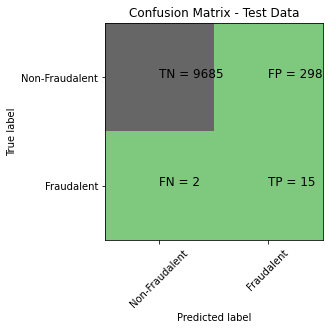

```
classification Report
              precision    recall  f1-score   support

           0       1.00      0.97      0.98      9983
           1       0.05      0.88      0.09        17

    accuracy                           0.97     10000
   macro avg       0.52      0.93      0.54     10000
weighted avg       1.00      0.97      0.98     10000

Accuarcy of Logistic model with l1 regularisation : 0.9983
Confusion Matrix
```

```
classification Report
              precision    recall  f1-score   support

           0       1.00      1.00      1.00      9983
           1       0.00      0.00      0.00        17

    accuracy                           1.00     10000
   macro avg       0.50      0.50      0.50     10000
weighted avg       1.00      1.00      1.00     10000

l2 roc_value: 0.9636470234693096
l2 threshold: 0.3707247623650453
ROC for the test dataset 96.4%
```

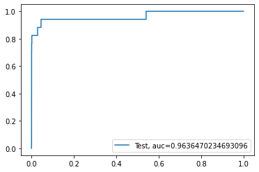

```
l1 roc_value: 0.5
l1 threshold: 1.5
ROC for the test dataset 50.0%
```

```
Time Taken by Model: --- 118.28125309944153 seconds ---
--------------------------------------------------------------------------------
KNN Model
model score
0.9925
Confusion Matrix
```

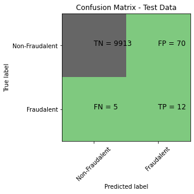

```
classification Report
              precision    recall  f1-score   support

           0       1.00      0.99      1.00      9983
           1       0.15      0.71      0.24        17

    accuracy                           0.99     10000
   macro avg       0.57      0.85      0.62     10000
weighted avg       1.00      0.99      0.99     10000

KNN roc_value: 0.8501540854747189
KNN threshold: 1.0
ROC for the test dataset 85.0%
```

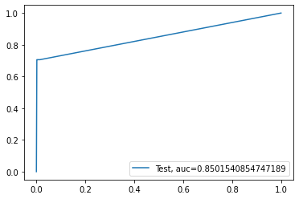

```
Time Taken by Model: --- 106.98998665809631 seconds ---
--------------------------------------------------------------------------------
Decision Tree Models with  'gini' & 'entropy' criteria
gini score: 0.9955
Confusion Matrix
```

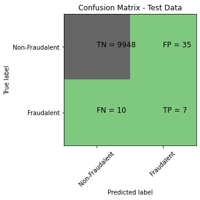

```
classification Report
              precision    recall  f1-score   support

           0       1.00      1.00      1.00      9983
           1       0.17      0.41      0.24        17

    accuracy                           1.00     10000
   macro avg       0.58      0.70      0.62     10000
weighted avg       1.00      1.00      1.00     10000

gini tree_roc_value: 0.704129372875064
Tree threshold: 1.0
ROC for the test dataset 70.4%
```

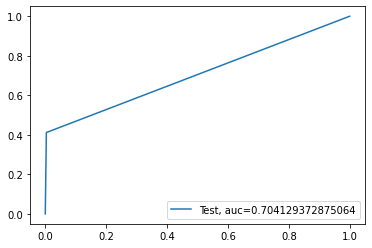

```
entropy score: 0.9974
Confusion Matrix
```

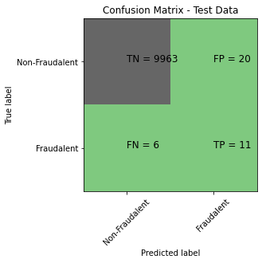

```
classification Report
              precision    recall  f1-score   support

           0       1.00      1.00      1.00      9983
           1       0.35      0.65      0.46        17

    accuracy                           1.00     10000
   macro avg       0.68      0.82      0.73     10000
weighted avg       1.00      1.00      1.00     10000

entropy tree_roc_value: 0.8225277088697844
Tree threshold: 1.0
ROC for the test dataset 82.3%
```

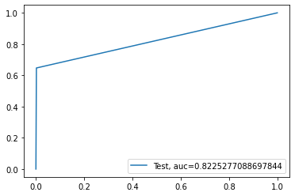

```
Time Taken by Model: --- 9.980096578598022 seconds ---
--------------------------------------------------------------------------------
Random Forest Model
Model Accuracy: 0.9995
Confusion Matrix
```

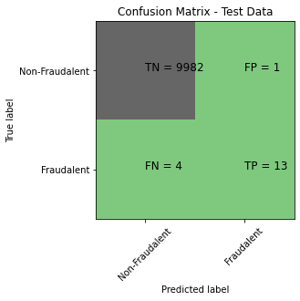

```
classification Report
              precision    recall  f1-score   support

           0       1.00      1.00      1.00      9983
           1       0.93      0.76      0.84        17

    accuracy                           1.00     10000
   macro avg       0.96      0.88      0.92     10000
weighted avg       1.00      1.00      1.00     10000

Random Forest roc_value: 0.9589478584181342
Random Forest threshold: 0.18
ROC for the test dataset 95.9%
```

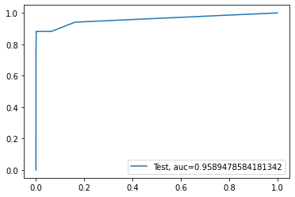

```
Time Taken by Model: --- 43.73682975769043 seconds ---
--------------------------------------------------------------------------------
XGBoost Model
Model Accuracy: 0.9948
Confusion Matrix
```

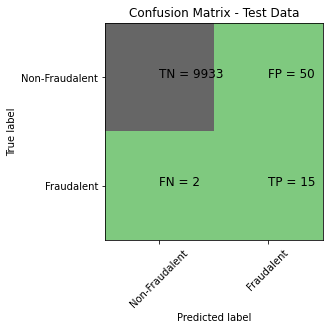

```
classification Report
              precision    recall  f1-score   support

           0       1.00      0.99      1.00      9983
           1       0.23      0.88      0.37        17

    accuracy                           0.99     10000
   macro avg       0.62      0.94      0.68     10000
weighted avg       1.00      0.99      1.00     10000

XGboost roc_value: 0.9464030027517367
XGBoost threshold: 0.5603106617927551
ROC for the test dataset 94.6%
```

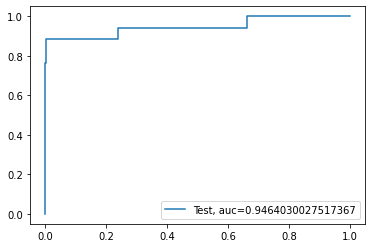

```
Time Taken by Model: --- 21.104939460754395 seconds ---
--------------------------------------------------------------------------------
ANN Model
accuracy_score : 0.9941
Confusion Matrix
```

[2 more figures not shown]

```
Time Taken by Model: --- 87.03782868385315 seconds ---
--------------------------------------------------------------------------------
```

```python
Data_Imbalance_Handiling	 = "SMOTE Oversampling with StratifiedKFold CV "
#Run Logistic Regression with L1 And L2 Regularisation
print("Logistic Regression with L1 And L2 Regularisation")
start_time = time.time()
df_Results = buildAndRunLogisticModels(df_Results, Data_Imbalance_Handiling, X_train_Smote, y_train_Smote , X_test, y_test)
print("Time Taken by Model: --- %s seconds ---" % (time.time() - start_time))
print('-'*80 )

#Run KNN Model
print("KNN Model")
start_time = time.time()
df_Results = buildAndRunKNNModels(df_Results, Data_Imbalance_Handiling, X_train_Smote, y_train_Smote , X_test, y_test)
print("Time Taken by Model: --- %s seconds ---" % (time.time() - start_time))
print('-'*80 )

#Run Decision Tree Models with  'gini' & 'entropy' criteria
print("Decision Tree Models with  'gini' & 'entropy' criteria")
start_time = time.time()
df_Results = buildAndRunTreeModels(df_Results, Data_Imbalance_Handiling, X_train_Smote, y_train_Smote , X_test, y_test)
print("Time Taken by Model: --- %s seconds ---" % (time.time() - start_time))
print('-'*80 )

#Run Random Forest Model
print("Random Forest Model")
start_time = time.time()
df_Results = buildAndRunRandomForestModels(df_Results, Data_Imbalance_Handiling, X_train_Smote, y_train_Smote , X_test, y_test)
print("Time Taken by Model: --- %s seconds ---" % (time.time() - start_time))
print('-'*80 )

#Run XGBoost Model
print("XGBoost Model")
start_time = time.time()
df_Results = buildAndRunXGBoostModels(df_Results, Data_Imbalance_Handiling, X_train_Smote, y_train_Smote , X_test, y_test)
print("Time Taken by Model: --- %s seconds ---" % (time.time() - start_time))
print('-'*80 )


#Run ANN Model
print("ANN Model")
start_time = time.time()
df_Results = buildAndgetmetricsANN(df_Results, Data_Imbalance_Handiling, X_train_Smote, y_train_Smote , X_test, y_test)
print("Time Taken by Model: --- %s seconds ---" % (time.time() - start_time))
print('-'*80 )
```

```python
# Checking the df_result dataframe which contains consolidated results of all the runs
df_Results
```

|  | Methodology | Model | Accuracy | roc_value | threshold |
| --- | --- | --- | --- | --- | --- |
| 0 | RepeatedKFold Cross Validation | Logistic Regression with L2 Regularisation | 0.9990 | 0.950886 | 0.030690 |
| 1 | RepeatedKFold Cross Validation | Logistic Regression with L1 Regularisation | 0.9991 | 0.933580 | 0.057833 |
| 2 | RepeatedKFold Cross Validation | KNN | 0.9990 | 0.866296 | 0.200000 |
| 3 | RepeatedKFold Cross Validation | Tree Model with gini criteria | 0.9989 | 0.833033 | 1.000000 |
| 4 | RepeatedKFold Cross Validation | Tree Model with entropy criteria | 0.9992 | 0.899750 | 1.000000 |
| 5 | RepeatedKFold Cross Validation | Random Forest | 0.9997 | 0.965381 | 0.300000 |
| 6 | RepeatedKFold Cross Validation | XGBoost | 0.9996 | 0.936365 | 0.283122 |
| 7 | RepeatedKFold Cross Validation | SVM | 0.9981 | 0.724487 | 0.003482 |
| 8 | RepeatedKFold Cross Validation | ANN | 0.9984 | 0.927278 | 0.000521 |
| 9 | StratifiedKFold Cross Validation | Logistic Regression with L2 Regularisation | 0.9992 | 0.956638 | 0.002113 |
| 10 | StratifiedKFold Cross Validation | Logistic Regression with L1 Regularisation | 0.9991 | 0.892559 | 0.301463 |
| 11 | StratifiedKFold Cross Validation | KNN | 0.9990 | 0.823250 | 0.200000 |
| 12 | StratifiedKFold Cross Validation | Tree Model with gini criteria | 0.9985 | 0.823079 | 1.000000 |
| 13 | StratifiedKFold Cross Validation | Tree Model with entropy criteria | 0.9990 | 0.823329 | 1.000000 |
| 14 | StratifiedKFold Cross Validation | Random Forest | 0.9995 | 0.937102 | 0.010000 |
| 15 | StratifiedKFold Cross Validation | XGBoost | 0.9993 | 0.971463 | 0.001395 |
| 16 | StratifiedKFold Cross Validation | SVM | 0.9975 | 0.634779 | 0.003424 |
| 17 | StratifiedKFold Cross Validation | ANN | 0.9985 | 0.925528 | 0.000077 |
| 18 | Random Oversampling with StratifiedKFold CV | Logistic Regression with L2 Regularisation | 0.9808 | 0.963078 | 0.383737 |
| 19 | Random Oversampling with StratifiedKFold CV | Logistic Regression with L1 Regularisation | 0.9983 | 0.500000 | 1.500000 |
| 20 | Random Oversampling with StratifiedKFold CV | KNN | 0.9986 | 0.823164 | 0.600000 |
| 21 | Random Oversampling with StratifiedKFold CV | Tree Model with gini criteria | 0.9987 | 0.793817 | 1.000000 |
| 22 | Random Oversampling with StratifiedKFold CV | Tree Model with entropy criteria | 0.9991 | 0.823379 | 1.000000 |
| 23 | Random Oversampling with StratifiedKFold CV | Random Forest | 0.9994 | 0.937891 | 0.020000 |
| 24 | Random Oversampling with StratifiedKFold CV | XGBoost | 0.9992 | 0.971475 | 0.135445 |
| 25 | Random Oversampling with StratifiedKFold CV | ANN | 0.9991 | 0.946933 | 0.000007 |
| 26 | SMOTE Oversampling with StratifiedKFold CV | Logistic Regression with L2 Regularisation | 0.9700 | 0.963647 | 0.370725 |
| 27 | SMOTE Oversampling with StratifiedKFold CV | Logistic Regression with L1 Regularisation | 0.9983 | 0.500000 | 1.500000 |
| 28 | SMOTE Oversampling with StratifiedKFold CV | KNN | 0.9925 | 0.850154 | 1.000000 |
| 29 | SMOTE Oversampling with StratifiedKFold CV | Tree Model with gini criteria | 0.9955 | 0.704129 | 1.000000 |
| 30 | SMOTE Oversampling with StratifiedKFold CV | Tree Model with entropy criteria | 0.9974 | 0.822528 | 1.000000 |
| 31 | SMOTE Oversampling with StratifiedKFold CV | Random Forest | 0.9995 | 0.958948 | 0.180000 |
| 32 | SMOTE Oversampling with StratifiedKFold CV | XGBoost | 0.9948 | 0.946403 | 0.560311 |
| 33 | SMOTE Oversampling with StratifiedKFold CV | ANN | 0.9941 | 0.944962 | 0.060091 |

## **Oversampling with ADASYN Oversampling**

**ADASYN (Adaptive Synthetic Sampling):**

- ADASYN (Adaptive Synthetic Sampling) is a data augmentation technique for handling imbalanced datasets by creating synthetic samples for the minority class with adaptive weighting.
- Unlike SMOTE, which generates synthetic samples for all minority class instances with equal weight, ADASYN assigns higher weights to minority class instances that are harder to classify, leading to a more balanced distribution of synthetic samples. This can help improve the performance of classification models on imbalanced datasets.

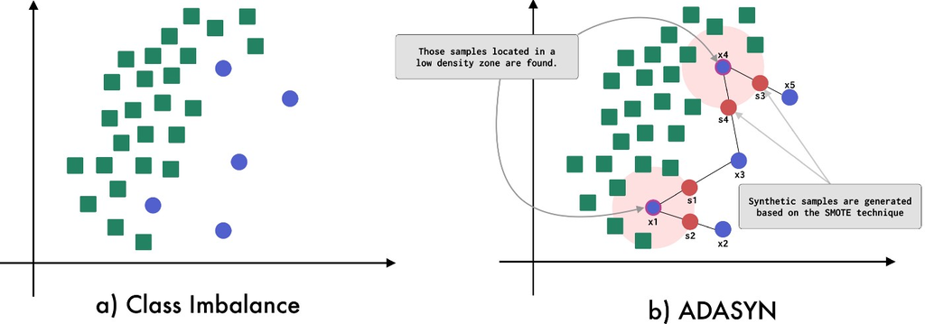

```python
# Creating dataframe with ADASYN and StratifiedKFold
from sklearn.model_selection import StratifiedKFold
from imblearn import over_sampling

skf = StratifiedKFold(n_splits=5, random_state=None)

for fold, (train_index, test_index) in enumerate(skf.split(X,y), 1):
    X_train = X.iloc[train_index]
    y_train = y.iloc[train_index]
    X_test = X.iloc[test_index]
    y_test = y.iloc[test_index]
    ADASYN = over_sampling.ADASYN(random_state=0)
    X_train_ADASYN, y_train_ADASYN= ADASYN.fit_resample(X_train, y_train)

X_train_ADASYN = pd.DataFrame(data=X_train_ADASYN,   columns=cols)
```

```
Logistic Regression with L1 And L2 Regularisation
Max auc_roc for l1: 0.5
Max auc_roc for l2: 0.990614868151021
Parameters for l1 regularisations
[[0. 0. 0. 0. 0. 0. 0. 0. 0. 0. 0. 0. 0. 0. 0. 0. 0. 0. 0. 0. 0. 0. 0. 0.
  0. 0. 0. 0. 0. 0.]]
[0.]
{1: array([[0.5, 0.5, 0.5, 0.5, 0.5, 0.5, 0.5, 0.5, 0.5, 0.5, 0.5, 0.5, 0.5,
        0.5, 0.5, 0.5, 0.5, 0.5, 0.5, 0.5],
       [0.5, 0.5, 0.5, 0.5, 0.5, 0.5, 0.5, 0.5, 0.5, 0.5, 0.5, 0.5, 0.5,
        0.5, 0.5, 0.5, 0.5, 0.5, 0.5, 0.5],
       [0.5, 0.5, 0.5, 0.5, 0.5, 0.5, 0.5, 0.5, 0.5, 0.5, 0.5, 0.5, 0.5,
        0.5, 0.5, 0.5, 0.5, 0.5, 0.5, 0.5],
       [0.5, 0.5, 0.5, 0.5, 0.5, 0.5, 0.5, 0.5, 0.5, 0.5, 0.5, 0.5, 0.5,
        0.5, 0.5, 0.5, 0.5, 0.5, 0.5, 0.5],
       [0.5, 0.5, 0.5, 0.5, 0.5, 0.5, 0.5, 0.5, 0.5, 0.5, 0.5, 0.5, 0.5,
        0.5, 0.5, 0.5, 0.5, 0.5, 0.5, 0.5],
       [0.5, 0.5, 0.5, 0.5, 0.5, 0.5, 0.5, 0.5, 0.5, 0.5, 0.5, 0.5, 0.5,
        0.5, 0.5, 0.5, 0.5, 0.5, 0.5, 0.5],
       [0.5, 0.5, 0.5, 0.5, 0.5, 0.5, 0.5, 0.5, 0.5, 0.5, 0.5, 0.5, 0.5,
        0.5, 0.5, 0.5, 0.5, 0.5, 0.5, 0.5],
       [0.5, 0.5, 0.5, 0.5, 0.5, 0.5, 0.5, 0.5, 0.5, 0.5, 0.5, 0.5, 0.5,
        0.5, 0.5, 0.5, 0.5, 0.5, 0.5, 0.5],
       [0.5, 0.5, 0.5, 0.5, 0.5, 0.5, 0.5, 0.5, 0.5, 0.5, 0.5, 0.5, 0.5,
        0.5, 0.5, 0.5, 0.5, 0.5, 0.5, 0.5],
       [0.5, 0.5, 0.5, 0.5, 0.5, 0.5, 0.5, 0.5, 0.5, 0.5, 0.5, 0.5, 0.5,
        0.5, 0.5, 0.5, 0.5, 0.5, 0.5, 0.5]])}
Parameters for l2 regularisations
[[ 1.83122538  3.05070972  1.12889673  1.03609642  2.19537452 -1.24143156
  -1.47721851  0.54078427  0.0192194  -1.43836518  1.73165582 -1.26261903
  -0.34025159 -2.96330909  0.2452743   0.39676769 -2.59767792 -2.16994575
   2.23465888 -2.04439939 -2.15269522  1.43232107  2.91884907 -0.03885319
   1.76321095 -1.04053388  1.69370689  2.81180162  0.02545477 -0.01301738]]
[-7.4042831]
{1: array([[0.60230187, 0.61016433, 0.65488978, 0.76861658, 0.89753741,
        0.9626292 , 0.9786859 , 0.98531415, 0.98823005, 0.98940061,
        0.99001333, 0.99001333, 0.99001333, 0.99001333, 0.99001333,
        0.99001333, 0.99001333, 0.99001333, 0.99001333, 0.99001333],
       [0.59198551, 0.59948425, 0.64389145, 0.7605135 , 0.89724268,
        0.9650588 , 0.98016343, 0.9861063 , 0.98882313, 0.98965897,
```

[output cut: 21 more lines]

```
        0.99035117, 0.99035117, 0.99035117, 0.99035117, 0.99035117],
       [0.59637601, 0.60460371, 0.65204751, 0.77517531, 0.90412903,
        0.96663064, 0.98115004, 0.98686483, 0.98953402, 0.99038293,
        0.99069029, 0.99069029, 0.99069029, 0.99069029, 0.99069029,
        0.99069029, 0.99069029, 0.99069029, 0.99069029, 0.99069029],
       [0.59538801, 0.60313171, 0.64776172, 0.76594601, 0.89834426,
        0.96513194, 0.97999818, 0.98602632, 0.98872745, 0.9897023 ,
        0.99006168, 0.99025806, 0.99025806, 0.99025806, 0.99025806,
        0.99025806, 0.99025806, 0.99025806, 0.99025806, 0.99025806],
       [0.59666165, 0.60404397, 0.64863165, 0.76404433, 0.89643651,
        0.96453479, 0.98061611, 0.98729169, 0.99019847, 0.99112301,
        0.99144929, 0.99144929, 0.99144929, 0.99144929, 0.99144929,
        0.99144929, 0.99144929, 0.99144929, 0.99144929, 0.99144929]])}
Accuarcy of Logistic model with l2 regularisation : 0.9567
Confusion Matrix
```

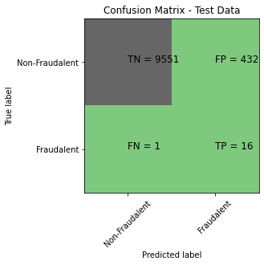

```
classification Report
              precision    recall  f1-score   support

           0       1.00      0.96      0.98      9983
           1       0.04      0.94      0.07        17

    accuracy                           0.96     10000
   macro avg       0.52      0.95      0.52     10000
weighted avg       1.00      0.96      0.98     10000

Accuarcy of Logistic model with l1 regularisation : 0.9983
Confusion Matrix
```

```
classification Report
              precision    recall  f1-score   support

           0       1.00      1.00      1.00      9983
           1       0.00      0.00      0.00        17

    accuracy                           1.00     10000
   macro avg       0.50      0.50      0.50     10000
weighted avg       1.00      1.00      1.00     10000

l2 roc_value: 0.964887367348021
l2 threshold: 0.5350685855528712
ROC for the test dataset 96.5%
```

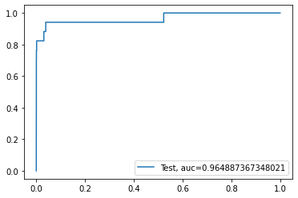

```
l1 roc_value: 0.5
l1 threshold: 1.5
ROC for the test dataset 50.0%
```

```
Time Taken by Model: --- 116.42573523521423 seconds ---
--------------------------------------------------------------------------------
KNN Model
model score
0.9919
Confusion Matrix
```

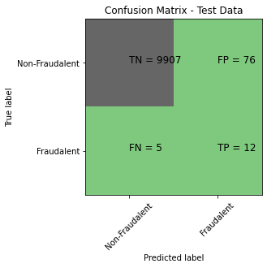

```
classification Report
              precision    recall  f1-score   support

           0       1.00      0.99      1.00      9983
           1       0.14      0.71      0.23        17

    accuracy                           0.99     10000
   macro avg       0.57      0.85      0.61     10000
weighted avg       1.00      0.99      0.99     10000

KNN roc_value: 0.8500804308500923
KNN threshold: 1.0
ROC for the test dataset 85.0%
```

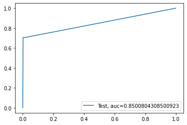

```
Time Taken by Model: --- 90.96645188331604 seconds ---
--------------------------------------------------------------------------------
Decision Tree Models with  'gini' & 'entropy' criteria
gini score: 0.9971
Confusion Matrix
```

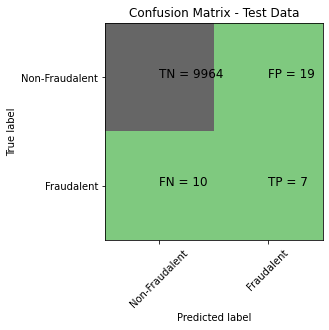

```
classification Report
              precision    recall  f1-score   support

           0       1.00      1.00      1.00      9983
           1       0.27      0.41      0.33        17

    accuracy                           1.00     10000
   macro avg       0.63      0.70      0.66     10000
weighted avg       1.00      1.00      1.00     10000

gini tree_roc_value: 0.7049307351910011
Tree threshold: 1.0
ROC for the test dataset 70.5%
```

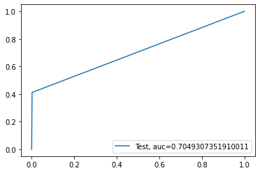

```
entropy score: 0.997
Confusion Matrix
```

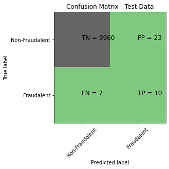

```
classification Report
              precision    recall  f1-score   support

           0       1.00      1.00      1.00      9983
           1       0.30      0.59      0.40        17

    accuracy                           1.00     10000
   macro avg       0.65      0.79      0.70     10000
weighted avg       1.00      1.00      1.00     10000

entropy tree_roc_value: 0.792965688729664
Tree threshold: 1.0
ROC for the test dataset 79.3%
```

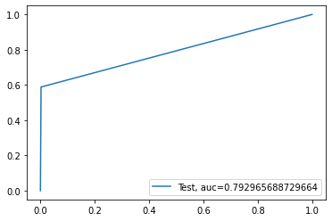

```
Time Taken by Model: --- 8.870583772659302 seconds ---
--------------------------------------------------------------------------------
Random Forest Model
Model Accuracy: 0.9993
Confusion Matrix
```

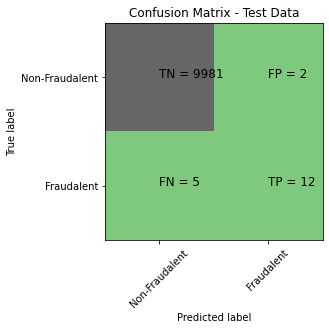

```
classification Report
              precision    recall  f1-score   support

           0       1.00      1.00      1.00      9983
           1       0.86      0.71      0.77        17

    accuracy                           1.00     10000
   macro avg       0.93      0.85      0.89     10000
weighted avg       1.00      1.00      1.00     10000

Random Forest roc_value: 0.9598876914283694
Random Forest threshold: 0.15
ROC for the test dataset 96.0%
```

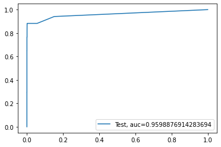

```
Time Taken by Model: --- 44.52493453025818 seconds ---
--------------------------------------------------------------------------------
XGBoost Model
Model Accuracy: 0.9941
Confusion Matrix
```

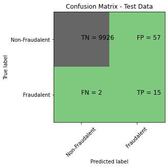

```
classification Report
              precision    recall  f1-score   support

           0       1.00      0.99      1.00      9983
           1       0.21      0.88      0.34        17

    accuracy                           0.99     10000
   macro avg       0.60      0.94      0.67     10000
weighted avg       1.00      0.99      1.00     10000

XGboost roc_value: 0.9527667623194724
XGBoost threshold: 0.575517475605011
ROC for the test dataset 95.3%
```

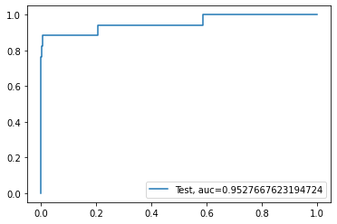

```
Time Taken by Model: --- 20.68782329559326 seconds ---
--------------------------------------------------------------------------------
ANN Model
accuracy_score : 0.998
Confusion Matrix
```

[2 more figures not shown]

```
Time Taken by Model: --- 84.96875286102295 seconds ---
--------------------------------------------------------------------------------
```

```python
Data_Imbalance_Handiling	 = "ADASYN Oversampling with StratifiedKFold CV "
#Run Logistic Regression with L1 And L2 Regularisation
print("Logistic Regression with L1 And L2 Regularisation")
start_time = time.time()
df_Results = buildAndRunLogisticModels(df_Results, Data_Imbalance_Handiling, X_train_ADASYN, y_train_ADASYN , X_test, y_test)
print("Time Taken by Model: --- %s seconds ---" % (time.time() - start_time))
print('-'*80 )

#Run KNN Model
print("KNN Model")
start_time = time.time()
df_Results = buildAndRunKNNModels(df_Results, Data_Imbalance_Handiling,X_train_ADASYN, y_train_ADASYN , X_test, y_test)
print("Time Taken by Model: --- %s seconds ---" % (time.time() - start_time))
print('-'*80 )

#Run Decision Tree Models with  'gini' & 'entropy' criteria
print("Decision Tree Models with  'gini' & 'entropy' criteria")
start_time = time.time()
df_Results = buildAndRunTreeModels(df_Results, Data_Imbalance_Handiling,X_train_ADASYN, y_train_ADASYN , X_test, y_test)
print("Time Taken by Model: --- %s seconds ---" % (time.time() - start_time))
print('-'*80 )

#Run Random Forest Model
print("Random Forest Model")
start_time = time.time()
df_Results = buildAndRunRandomForestModels(df_Results, Data_Imbalance_Handiling,X_train_ADASYN, y_train_ADASYN , X_test, y_test)
print("Time Taken by Model: --- %s seconds ---" % (time.time() - start_time))
print('-'*80 )

#Run XGBoost Model
print("XGBoost Model")
start_time = time.time()
df_Results = buildAndRunXGBoostModels(df_Results, Data_Imbalance_Handiling,X_train_ADASYN, y_train_ADASYN , X_test, y_test)
print("Time Taken by Model: --- %s seconds ---" % (time.time() - start_time))
print('-'*80 )

#Run ANN Model
print("ANN Model")
start_time = time.time()
df_Results = buildAndgetmetricsANN(df_Results, Data_Imbalance_Handiling, X_train_Smote, y_train_Smote , X_test, y_test)
print("Time Taken by Model: --- %s seconds ---" % (time.time() - start_time))
print('-'*80 )
```

```python
# Checking the df_result dataframe which contains consolidated results of all the runs
df_Results
```

|  | Methodology | Model | Accuracy | roc_value | threshold |
| --- | --- | --- | --- | --- | --- |
| 0 | RepeatedKFold Cross Validation | Logistic Regression with L2 Regularisation | 0.9990 | 0.950886 | 0.030690 |
| 1 | RepeatedKFold Cross Validation | Logistic Regression with L1 Regularisation | 0.9991 | 0.933580 | 0.057833 |
| 2 | RepeatedKFold Cross Validation | KNN | 0.9990 | 0.866296 | 0.200000 |
| 3 | RepeatedKFold Cross Validation | Tree Model with gini criteria | 0.9989 | 0.833033 | 1.000000 |
| 4 | RepeatedKFold Cross Validation | Tree Model with entropy criteria | 0.9992 | 0.899750 | 1.000000 |
| 5 | RepeatedKFold Cross Validation | Random Forest | 0.9997 | 0.965381 | 0.300000 |
| 6 | RepeatedKFold Cross Validation | XGBoost | 0.9996 | 0.936365 | 0.283122 |
| 7 | RepeatedKFold Cross Validation | SVM | 0.9981 | 0.724487 | 0.003482 |
| 8 | RepeatedKFold Cross Validation | ANN | 0.9984 | 0.927278 | 0.000521 |
| 9 | StratifiedKFold Cross Validation | Logistic Regression with L2 Regularisation | 0.9992 | 0.956638 | 0.002113 |
| 10 | StratifiedKFold Cross Validation | Logistic Regression with L1 Regularisation | 0.9991 | 0.892559 | 0.301463 |
| 11 | StratifiedKFold Cross Validation | KNN | 0.9990 | 0.823250 | 0.200000 |
| 12 | StratifiedKFold Cross Validation | Tree Model with gini criteria | 0.9985 | 0.823079 | 1.000000 |
| 13 | StratifiedKFold Cross Validation | Tree Model with entropy criteria | 0.9990 | 0.823329 | 1.000000 |
| 14 | StratifiedKFold Cross Validation | Random Forest | 0.9995 | 0.937102 | 0.010000 |
| 15 | StratifiedKFold Cross Validation | XGBoost | 0.9993 | 0.971463 | 0.001395 |
| 16 | StratifiedKFold Cross Validation | SVM | 0.9975 | 0.634779 | 0.003424 |
| 17 | StratifiedKFold Cross Validation | ANN | 0.9985 | 0.925528 | 0.000077 |
| 18 | Random Oversampling with StratifiedKFold CV | Logistic Regression with L2 Regularisation | 0.9808 | 0.963078 | 0.383737 |
| 19 | Random Oversampling with StratifiedKFold CV | Logistic Regression with L1 Regularisation | 0.9983 | 0.500000 | 1.500000 |
| 20 | Random Oversampling with StratifiedKFold CV | KNN | 0.9986 | 0.823164 | 0.600000 |
| 21 | Random Oversampling with StratifiedKFold CV | Tree Model with gini criteria | 0.9987 | 0.793817 | 1.000000 |
| 22 | Random Oversampling with StratifiedKFold CV | Tree Model with entropy criteria | 0.9991 | 0.823379 | 1.000000 |
| 23 | Random Oversampling with StratifiedKFold CV | Random Forest | 0.9994 | 0.937891 | 0.020000 |
| 24 | Random Oversampling with StratifiedKFold CV | XGBoost | 0.9992 | 0.971475 | 0.135445 |
| 25 | Random Oversampling with StratifiedKFold CV | ANN | 0.9991 | 0.946933 | 0.000007 |
| 26 | SMOTE Oversampling with StratifiedKFold CV | Logistic Regression with L2 Regularisation | 0.9700 | 0.963647 | 0.370725 |
| 27 | SMOTE Oversampling with StratifiedKFold CV | Logistic Regression with L1 Regularisation | 0.9983 | 0.500000 | 1.500000 |
| 28 | SMOTE Oversampling with StratifiedKFold CV | KNN | 0.9925 | 0.850154 | 1.000000 |
| 29 | SMOTE Oversampling with StratifiedKFold CV | Tree Model with gini criteria | 0.9955 | 0.704129 | 1.000000 |
| 30 | SMOTE Oversampling with StratifiedKFold CV | Tree Model with entropy criteria | 0.9974 | 0.822528 | 1.000000 |
| 31 | SMOTE Oversampling with StratifiedKFold CV | Random Forest | 0.9995 | 0.958948 | 0.180000 |
| 32 | SMOTE Oversampling with StratifiedKFold CV | XGBoost | 0.9948 | 0.946403 | 0.560311 |
| 33 | SMOTE Oversampling with StratifiedKFold CV | ANN | 0.9941 | 0.944962 | 0.060091 |
| 34 | ADASYN Oversampling with StratifiedKFold CV | Logistic Regression with L2 Regularisation | 0.9567 | 0.964887 | 0.535069 |
| 35 | ADASYN Oversampling with StratifiedKFold CV | Logistic Regression with L1 Regularisation | 0.9983 | 0.500000 | 1.500000 |
| 36 | ADASYN Oversampling with StratifiedKFold CV | KNN | 0.9919 | 0.850080 | 1.000000 |
| 37 | ADASYN Oversampling with StratifiedKFold CV | Tree Model with gini criteria | 0.9971 | 0.704931 | 1.000000 |
| 38 | ADASYN Oversampling with StratifiedKFold CV | Tree Model with entropy criteria | 0.9970 | 0.792966 | 1.000000 |
| 39 | ADASYN Oversampling with StratifiedKFold CV | Random Forest | 0.9993 | 0.959888 | 0.150000 |
| 40 | ADASYN Oversampling with StratifiedKFold CV | XGBoost | 0.9941 | 0.952767 | 0.575517 |
| 41 | ADASYN Oversampling with StratifiedKFold CV | ANN | 0.9980 | 0.953533 | 0.001770 |

## **Overall conclusion after running the models on Oversampled data:**

- Looking at above results it seems XGBOOST model with Random Oversampling with StratifiedKFold CV has provided the best results under the category of all oversampling techniques. So we will try to tune the hyperparameters of this model to get best results.

## **Hyperparameter Tuning**

```python
# Performing Hyperparameter tuning
from xgboost.sklearn import XGBClassifier
from sklearn.model_selection import GridSearchCV,RandomizedSearchCV
param_test = {
 'max_depth':range(3,10,2),
 'min_child_weight':range(1,6,2),
 'n_estimators':range(60,130,150),
 'learning_rate':[0.05,0.1,0.125,0.15,0.2],
 'gamma':[i/10.0 for i in range(0,5)],
 'subsample':[i/10.0 for i in range(7,10)],
 'colsample_bytree':[i/10.0 for i in range(7,10)]
}

gsearch1 = RandomizedSearchCV(estimator = XGBClassifier(base_score=0.5, booster='gbtree', colsample_bylevel=1,
              colsample_bynode=1,max_delta_step=0,
              missing=None, n_jobs=-1,
              nthread=None, objective='binary:logistic', random_state=42,
              reg_alpha=0, reg_lambda=1, scale_pos_weight=1, seed=None,
              silent=None, verbosity=1),
              param_distributions = param_test, n_iter=5,scoring='roc_auc',n_jobs=-1, cv=5)

gsearch1.fit(X_over, y_over)
gsearch1.cv_results_, gsearch1.best_params_, gsearch1.best_score_
```

```
({'mean_fit_time': array([ 7.95628734, 17.85095525,  7.41580715, 13.04083924, 17.3790236 ]),
  'std_fit_time': array([0.84154201, 0.32982394, 0.63760971, 0.41301149, 1.98682468]),
  'mean_score_time': array([0.05614347, 0.06945863, 0.05744319, 0.06470861, 0.05429459]),
  'std_score_time': array([0.01722913, 0.01862621, 0.02510229, 0.01841114, 0.00632305]),
  'param_subsample': masked_array(data=[0.9, 0.9, 0.7, 0.7, 0.8],
               mask=[False, False, False, False, False],
         fill_value='?',
              dtype=object),
  'param_n_estimators': masked_array(data=[60, 60, 60, 60, 60],
               mask=[False, False, False, False, False],
         fill_value='?',
              dtype=object),
  'param_min_child_weight': masked_array(data=[1, 3, 1, 1, 3],
               mask=[False, False, False, False, False],
         fill_value='?',
              dtype=object),
  'param_max_depth': masked_array(data=[3, 9, 3, 5, 9],
               mask=[False, False, False, False, False],
         fill_value='?',
              dtype=object),
  'param_learning_rate': masked_array(data=[0.15, 0.1, 0.15, 0.1, 0.1],
               mask=[False, False, False, False, False],
         fill_value='?',
              dtype=object),
  'param_gamma': masked_array(data=[0.4, 0.4, 0.3, 0.4, 0.3],
               mask=[False, False, False, False, False],
         fill_value='?',
              dtype=object),
  'param_colsample_bytree': masked_array(data=[0.7, 0.8, 0.7, 0.9, 0.8],
               mask=[False, False, False, False, False],
         fill_value='?',
              dtype=object),
  'params': [{'subsample': 0.9,
    'n_estimators': 60,
    'min_child_weight': 1,
    'max_depth': 3,
    'learning_rate': 0.15,
    'gamma': 0.4,
    'colsample_bytree': 0.7},
   {'subsample': 0.9,
```

[output cut: 29 more lines]

```
  'split2_test_score': array([0.99972677, 0.99999417, 0.99979866, 0.99990744, 0.99997796]),
  'split3_test_score': array([0.99989202, 0.99992623, 0.99987478, 0.99988858, 0.99992124]),
  'split4_test_score': array([0.99993421, 1.        , 0.99992461, 0.99998018, 0.99998206]),
  'mean_test_score': array([0.99986146, 0.99997714, 0.99987086, 0.99993757, 0.99997073]),
  'std_test_score': array([7.46656402e-05, 2.85217757e-05, 5.17106231e-05, 3.58332424e-05,
         2.64156355e-05]),
  'rank_test_score': array([5, 1, 4, 3, 2], dtype=int32)},
 {'subsample': 0.9,
  'n_estimators': 60,
  'min_child_weight': 3,
  'max_depth': 9,
  'learning_rate': 0.1,
  'gamma': 0.4,
  'colsample_bytree': 0.8},
 0.9999771372442581)
```

- Please note that the hyperparameters found above using RandomizedSearchCV and the hyperparameters used below in creating the final model might be different, the reason being, I have executed the RandomizedSearchCV multiple times to find which set of hyperparameters gives the optimum result and finally used the one below which gave me the best performance.

```python
# Creating XGBoost model with selected hyperparameters
from xgboost import XGBClassifier

clf = XGBClassifier(base_score=0.5, booster='gbtree', colsample_bylevel=1,
              colsample_bynode=1, colsample_bytree=0.7, gamma=0.2,
              learning_rate=0.125, max_delta_step=0, max_depth=7,
              min_child_weight=5, missing=None, n_estimators=60, n_jobs=1,
              nthread=None, objective='binary:logistic', random_state=42,
              reg_alpha=0, reg_lambda=1, scale_pos_weight=1, seed=None,
              silent=None, subsample=0.8, verbosity=1)

# fit on the dataset
clf.fit(X_over, y_over )
XGB_test_score = clf.score(X_test, y_test)
print('Model Accuracy: {0}'.format(XGB_test_score))

# Probabilities for each class
XGB_probs = clf.predict_proba(X_test)[:, 1]

# Calculate roc auc
XGB_roc_value = roc_auc_score(y_test, XGB_probs)

print("XGboost roc_value: {0}" .format(XGB_roc_value))
fpr, tpr, thresholds = metrics.roc_curve(y_test, XGB_probs)
threshold = thresholds[np.argmax(tpr-fpr)]
print("XGBoost threshold: {0}".format(threshold))
```

```
Model Accuracy: 0.9991
XGboost roc_value: 0.9680280005420979
XGBoost threshold: 0.0020904664415866137
```

### **Print the important features of the best model to understand the dataset**

```python
imp_var = []
for i in clf.feature_importances_:
    imp_var.append(i)
print('Top var =', imp_var.index(np.sort(clf.feature_importances_)[-1])+1)
print('2nd Top var =', imp_var.index(np.sort(clf.feature_importances_)[-2])+1)
print('3rd Top var =', imp_var.index(np.sort(clf.feature_importances_)[-3])+1)
```

```
Top var = 14
2nd Top var = 17
3rd Top var = 10
```

```python
# Calculate roc auc
XGB_roc_value = roc_auc_score(y_test, XGB_probs)

print("XGboost roc_value: {0}" .format(XGB_roc_value))
fpr, tpr, thresholds = metrics.roc_curve(y_test, XGB_probs)
threshold = thresholds[np.argmax(tpr-fpr)]
print("XGBoost threshold: {0}".format(threshold))
```

```
XGboost roc_value: 0.9680280005420979
XGBoost threshold: 0.0020904664415866137
```

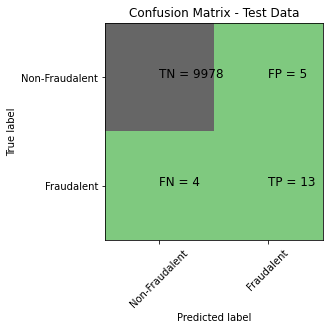

```python
# Confusion matrix
Plot_confusion_matrix(y_test,clf.predict(X_test))
```

## **Conclusion**

- In the oversample cases, of all the models we build found that the XGBOOST model with Random Oversampling with StratifiedKFold CV gave us the best accuracy and ROC on oversampled data. Post that we performed hyperparameter tuning and got the below metrices :
  - XGboost roc_value: 0.9680280005420979
  - XGBoost threshold: 0.0020904664415866137
- However, of all the models we created we found Logistic Regression with L2 Regularisation for StratifiedKFold cross validation (without any oversampling or undersampling) gave us the best result.
- Also, all the models we created gave good results